# gensim - reproducible training

## EmbeddingVectorzier -W2V

```python
# basic

import pandas as pd
import numpy as np
import warnings
warnings.filterwarnings('ignore')
pd.set_option('display.max_columns', 50, 'display.max_rows', 200)
import os
#os.environ["PYTHONHASHSEED"] = "123"


# plot

import seaborn as sns
import matplotlib.pylab as plt
from matplotlib import font_manager, rc
%matplotlib inline

import platform
your_os = platform.system()
if your_os == 'Linux':
    rc('font', family='NanumGothic')
elif your_os == 'Windows':
    ttf = "c:/Windows/Fonts/malgun.ttf"
    font_name = font_manager.FontProperties(fname=ttf).get_name()
    rc('font', family=font_name)
elif your_os == 'Darwin':
    rc('font', family='AppleGothic')
rc('axes', unicode_minus=False)


# models
import time
from tqdm import tqdm
from sklearn.model_selection import train_test_split
from sklearn.model_selection import cross_val_score
from sklearn.metrics import roc_auc_score
from sklearn.model_selection import StratifiedKFold, KFold

from sklearn.decomposition import PCA
from sklearn.feature_selection import SelectPercentile
import shap
from scipy.stats.mstats import gmean
from sklearn.preprocessing import MinMaxScaler
from sklearn.model_selection import ShuffleSplit
from sklearn.preprocessing import OneHotEncoder

from sklearn.ensemble import RandomForestClassifier
from sklearn.neighbors import KNeighborsClassifier
from sklearn.linear_model import LogisticRegression
from sklearn.svm import SVC
from sklearn.ensemble import GradientBoostingClassifier
from lightgbm import LGBMClassifier
from xgboost import XGBClassifier
from sklearn.neural_network import MLPClassifier
from sklearn.ensemble import ExtraTreesClassifier
from catboost import CatBoostClassifier
from sklearn.cluster import KMeans

from sklearn.model_selection import GridSearchCV, RandomizedSearchCV
from bayes_opt import BayesianOptimization
from sklearn.ensemble import VotingClassifier
from vecstack import StackingTransformer
from vecstack import stacking

from gensim.models import word2vec
from sklearn.pipeline import Pipeline
from gensim.models import doc2vec
from gensim.models.doc2vec import Doc2Vec, TaggedDocument
from nltk.tokenize import word_tokenize
```

```python
### Read data
df_train = pd.read_csv('X_train.csv', encoding='cp949')
df_test = pd.read_csv('X_test.csv', encoding='cp949')
y_train = pd.read_csv('y_train.csv').gender
IDtest = df_test.cust_id.unique()

skf = StratifiedKFold(n_splits=4, shuffle=True, random_state=0)
```

```python
### Make corpus: corpus는 말뭉치라는 뜻임

# oversample2: unique사용 X, 비복원추출 -> 복원추출
# data는 X_train 또는 X_test가 될 것
# p_level은 대, 중, 소분류중에 하나 넣기('gds_grp_mclas_nm', 'gds_grp_nm', 'goods_id')
# n은 몇번 오버샘플링 할 것인지 -> 1일때 기본 + 오버샘플링, 2일때 기본 + 오버샘플링2
#                               -> 고객리스트가 10개인데 n값이 1이면 고객리스트를 20개(기본(10) + 오버샘플링(10))로 반환
#                               -> 고객리스트가 10개인데 n값이 2이면 고객리스트를 30개(기본(10) + 오버샘플링(20))로 반환

def oversample2(data, p_level, n=1, seed=0):

    np.random.seed(seed)

    cust_ids = data['cust_id'].unique().tolist()

    customerProducts = []

    for cust_id in cust_ids:

        productLst = data.query(f'cust_id=={cust_id}')[p_level].tolist()

        for j in range(n):

            productLst = list(np.append(productLst, np.random.choice(productLst, len(productLst) * n, replace=True)))

        customerProducts.append(productLst)

    return customerProducts
```

```python
# 중분류 구매목록
print('중분류 구매목록 뽑는중')
X_train_corpus_nm = oversample2(df_train,'gds_grp_nm', 2)
X_test_corpus_nm = oversample2(df_test,'gds_grp_nm', 2)
```

```
중분류 구매목록 뽑는중
```

```python
# 중분류 구매목록
print('중분류 구매목록 뽑는중')
X_train_corpus_mclas_nm = oversample2(df_train,'gds_grp_mclas_nm', 2)
X_test_corpus_mclas_nm = oversample2(df_test,'gds_grp_mclas_nm', 2)
```

```
중분류 구매목록 뽑는중
```

```python
### Training the Word2Vec model
num_features = 300 # 단어 벡터 차원 수
min_word_count = 1 # 최소 단어 수
context = 10 # 학습 윈도우(인접한 단어 리스트) 크기

# 중분류
print('중분류 학습중')
w2v_nm = word2vec.Word2Vec(X_train_corpus_nm,                  # 학습시킬 단어 리스트
                        size=num_features,        # 단어 벡터의 차원 수
                        window=context,           # 주변 단어(window)는 안뒤로 몇개까지 볼 것인지
                        min_count=min_word_count, # 단어 리스트에서 출현 빈도가 몇번 미만인 단어는 분석에서 제외해라
                        workers=4,                # cpu는 쿼드코어를 써라 n_jobs=-1과 같음
                        sg = 1,                   # CBOW와 skip-gram중 후자를 선택
                        iter=7,
                        seed=0)

# 필요없는 메모리 unload
w2v_nm.init_sims(replace=True)



# 대분류
print('대분류 학습중')
w2v_mclas_nm = word2vec.Word2Vec(X_train_corpus_mclas_nm,                  # 학습시킬 단어 리스트
                        size=num_features,        # 단어 벡터의 차원 수
                        window=context,           # 주변 단어(window)는 안뒤로 몇개까지 볼 것인지
                        min_count=min_word_count, # 단어 리스트에서 출현 빈도가 몇번 미만인 단어는 분석에서 제외해라
                        workers=4,                # cpu는 쿼드코어를 써라 n_jobs=-1과 같음
                        sg = 1,                   # CBOW와 skip-gram중 후자를 선택
                        iter=7,
                        seed=0)

# 필요없는 메모리 unload
w2v_mclas_nm.init_sims(replace=True)
```

```
중분류 학습중
대분류 학습중
```

```python
### Make features
# 구매상품에 해당하는 벡터의 평균/최소/최대 벡터를 feature로 만드는 전처리기(pipeline에서 사용 가능)
class EmbeddingVectorizer_nm(object):
    def __init__(self, word2vec):
        self.word2vec = word2vec
        self.dim = num_features
    def fit(self, X, y):
        return self
    def transform(self, X):
        return np.array([
            np.hstack([
                np.std([self.word2vec[w] for w in words if w in self.word2vec] or [np.zeros(self.dim)], axis=0),
                np.var([self.word2vec[w] for w in words if w in self.word2vec] or [np.zeros(self.dim)], axis=0),
            ])
            for words in X
        ])
```

```python
### Make features
# 구매상품에 해당하는 벡터의 평균/최소/최대 벡터를 feature로 만드는 전처리기(pipeline에서 사용 가능)
class EmbeddingVectorizer_mclas(object):
    def __init__(self, word2vec):
        self.word2vec = word2vec
        self.dim = num_features
    def fit(self, X, y):
        return self
    def transform(self, X):
        return np.array([
            np.hstack([
                np.max([self.word2vec[w] for w in words if w in self.word2vec] or [np.zeros(self.dim)], axis=0),
                np.min([self.word2vec[w] for w in words if w in self.word2vec] or [np.zeros(self.dim)], axis=0),
            ])
            for words in X
        ])
```

```python
# EmbeddingVectorizer 클래스를 통해서 피쳐뽑기(std, max, var -> 600개 피쳐나옴)

# 중분류
Vectorizer = EmbeddingVectorizer_nm(w2v_nm.wv)
Vectorizer.fit(X_train_corpus_nm, y_train)

X_train_nm = pd.DataFrame(Vectorizer.transform(X_train_corpus_nm))
X_test_nm = pd.DataFrame(Vectorizer.transform(X_test_corpus_nm))

display(X_train_nm)
```

|  | 0 | 1 | 2 | 3 | 4 | 5 | 6 | 7 | 8 | 9 | 10 | 11 | 12 | 13 | 14 | 15 | 16 | 17 | 18 | 19 | 20 | 21 | 22 | 23 | 24 | ... | 575 | 576 | 577 | … |
| --- | --- | --- | --- | --- | --- | --- | --- | --- | --- | --- | --- | --- | --- | --- | --- | --- | --- | --- | --- | --- | --- | --- | --- | --- | --- | --- | --- | --- | --- | --- |
| 0 | 5.899665e-02 | 5.280996e-02 | 4.896489e-02 | 4.692144e-02 | 5.887605e-02 | 3.703730e-02 | 4.528708e-02 | 0.056775 | 4.558063e-02 | 4.952119e-02 | 5.959244e-02 | 4.511775e-02 | 5.462449e-02 | 4.705761e-02 | 0.061487 | 5.883342e-02 | 2.512778e-02 | 4.515208e-02 | 4.507128e-02 | 0.050417 | 0.037349 | 4.976974e-02 | 4.951488e-02 | 3.703742e-02 | 4.567186e-02 | ... | 1.574418e-03 | 0.001319 | 3.143304e-03 | … |
| 1 | 4.440968e-02 | 3.742162e-02 | 5.923415e-02 | 2.783321e-02 | 2.523422e-02 | 7.106266e-03 | 3.267865e-02 | 0.005263 | 2.856833e-02 | 7.226545e-02 | 2.235206e-02 | 9.817278e-03 | 2.250186e-02 | 1.426914e-02 | 0.024142 | 2.960102e-02 | 2.988188e-02 | 1.449286e-02 | 5.052224e-02 | 0.012466 | 0.006994 | 1.225173e-03 | 3.484410e-02 | 7.933024e-02 | 5.527479e-02 | ... | 3.662446e-03 | 0.000111 | 1.075966e-03 | … |
| 2 | 3.381081e-02 | 8.462013e-03 | 8.081478e-02 | 3.126807e-03 | 3.733460e-02 | 4.156350e-02 | 6.252491e-02 | 0.003031 | 3.383411e-02 | 2.499662e-02 | 1.678573e-02 | 1.322571e-02 | 1.331047e-02 | 1.990806e-02 | 0.026797 | 4.470570e-02 | 5.285054e-03 | 3.717316e-02 | 9.725036e-03 | 0.000963 | 0.000839 | 7.777274e-03 | 4.730411e-02 | 2.759685e-03 | 2.173524e-02 | ... | 1.224733e-05 | 0.000030 | 2.512346e-03 | … |
| 3 | 4.476567e-02 | 3.724468e-02 | 6.270374e-02 | 3.711123e-02 | 4.323265e-02 | 3.776972e-02 | 3.849525e-02 | 0.041409 | 2.866256e-02 | 4.330871e-02 | 5.383167e-02 | 3.393687e-02 | 4.525302e-02 | 2.844671e-02 | 0.029419 | 5.589782e-02 | 2.943322e-02 | 3.370453e-02 | 3.045639e-02 | 0.040457 | 0.046573 | 4.675895e-02 | 2.942423e-02 | 4.083059e-02 | 3.134383e-02 | ... | 1.083091e-03 | 0.001145 | 1.644589e-03 | … |
| 4 | 6.251881e-02 | 2.899562e-02 | 1.460668e-02 | 6.149970e-02 | 4.184485e-02 | 5.260567e-02 | 4.462630e-02 | 0.063573 | 3.777427e-02 | 4.822346e-02 | 6.022044e-02 | 2.236826e-02 | 2.380999e-02 | 1.820231e-02 | 0.046688 | 5.210932e-02 | 1.958533e-02 | 2.550013e-02 | 1.182246e-02 | 0.022583 | 0.020502 | 5.179163e-02 | 5.374951e-02 | 2.011977e-02 | 7.367784e-02 | ... | 9.113579e-05 | 0.001637 | 1.904305e-03 | … |
| ... | ... | ... | ... | ... | ... | ... | ... | ... | ... | ... | ... | ... | ... | ... | ... | ... | ... | ... | ... | ... | ... | ... | ... | ... | ... | ... | ... | ... | ... | … |
| 3495 | 4.867327e-03 | 1.004821e-02 | 1.841670e-03 | 1.046062e-02 | 1.225543e-02 | 3.247649e-02 | 3.132902e-03 | 0.016049 | 3.362139e-02 | 8.664630e-02 | 6.594805e-03 | 1.763941e-02 | 5.992286e-02 | 1.350976e-02 | 0.029732 | 2.829801e-02 | 7.291049e-03 | 9.632668e-03 | 1.842618e-02 | 0.045679 | 0.010909 | 1.522550e-03 | 1.179132e-02 | 1.487208e-02 | 5.360587e-03 | ... | 6.825340e-05 | 0.000539 | 9.064272e-04 | … |
| 3496 | 4.646836e-02 | 7.465217e-02 | 3.738804e-02 | 2.867129e-02 | 2.526517e-02 | 2.221232e-02 | 5.093722e-02 | 0.046614 | 3.622800e-02 | 5.158681e-02 | 8.424698e-02 | 1.986091e-02 | 6.063771e-02 | 7.796669e-02 | 0.050515 | 5.133567e-02 | 3.175574e-02 | 3.903417e-02 | 5.288789e-02 | 0.051552 | 0.055567 | 3.070233e-02 | 3.034973e-02 | 2.393414e-02 | 3.446943e-02 | ... | 1.112564e-03 | 0.001288 | 6.904982e-03 | … |
| 3497 | 0.000000e+00 | 3.725290e-09 | 0.000000e+00 | 0.000000e+00 | 0.000000e+00 | 4.656613e-10 | 0.000000e+00 | 0.000000 | 0.000000e+00 | 0.000000e+00 | 1.862645e-09 | 4.656613e-10 | 0.000000e+00 | 3.725290e-09 | 0.000000 | 0.000000e+00 | 1.862645e-09 | 0.000000e+00 | 0.000000e+00 | 0.000000 | 0.000000 | 0.000000e+00 | 0.000000e+00 | 3.725290e-09 | 0.000000e+00 | ... | 3.469447e-18 | 0.000000 | 0.000000e+00 | … |
| 3498 | 7.450581e-09 | 7.450581e-09 | 1.396984e-09 | 1.490116e-08 | 3.725290e-09 | 0.000000e+00 | 7.450581e-09 | 0.000000 | 5.587935e-09 | 1.396984e-09 | 7.450581e-09 | 0.000000e+00 | 1.117587e-08 | 7.450581e-09 | 0.000000 | 3.725290e-09 | 5.587935e-09 | 1.164153e-10 | 1.490116e-08 | 0.000000 | 0.000000 | 7.450581e-09 | 2.235174e-08 | 0.000000e+00 | 1.490116e-08 | ... | 2.168404e-19 | 0.000000 | 5.551115e-17 | … |
| 3499 | 5.208909e-02 | 5.933618e-02 | 6.242974e-02 | 4.289356e-02 | 3.734662e-02 | 5.185428e-02 | 4.779614e-02 | 0.056293 | 4.049378e-02 | 5.785516e-02 | 7.573969e-02 | 4.436250e-02 | 4.376474e-02 | 5.416920e-02 | 0.049779 | 5.782526e-02 | 4.508354e-02 | 5.732210e-02 | 4.236741e-02 | 0.060247 | 0.039065 | 4.189559e-02 | 4.254751e-02 | 4.341828e-02 | 4.848241e-02 | ... | 1.888017e-03 | 0.001925 | 3.078085e-03 | … |

3500 rows × 600 columns

```python
# EmbeddingVectorizer 클래스를 통해서 피쳐뽑기(std, max, var -> 600개 피쳐나옴)

# 중분류
Vectorizer = EmbeddingVectorizer_mclas(w2v_mclas_nm.wv)
Vectorizer.fit(X_train_corpus_mclas_nm, y_train)

X_train_mclas = pd.DataFrame(Vectorizer.transform(X_train_corpus_mclas_nm))
X_test_mclas = pd.DataFrame(Vectorizer.transform(X_test_corpus_mclas_nm))

display(X_train_mclas)
```

|  | 0 | 1 | 2 | 3 | 4 | 5 | 6 | 7 | 8 | 9 | 10 | 11 | 12 | 13 | 14 | 15 | 16 | 17 | 18 | 19 | 20 | 21 | 22 | 23 | 24 | ... | 575 | 576 | 577 | … |
| --- | --- | --- | --- | --- | --- | --- | --- | --- | --- | --- | --- | --- | --- | --- | --- | --- | --- | --- | --- | --- | --- | --- | --- | --- | --- | --- | --- | --- | --- | --- |
| 0 | 0.174072 | 0.265981 | 0.196587 | 0.096481 | 0.099925 | 0.046536 | 0.145079 | 0.066760 | -0.007020 | 0.168740 | 0.088188 | 0.166307 | 0.110887 | 0.148301 | 0.126536 | 0.116817 | 0.111467 | 0.071353 | 0.043774 | 0.026025 | 0.119931 | 0.055466 | 0.114719 | 0.020517 | 0.084407 | ... | -0.038545 | -0.045669 | -0.055630 | … |
| 1 | 0.174072 | 0.068778 | 0.111550 | -0.012871 | 0.001516 | -0.039886 | -0.036712 | -0.080081 | -0.033167 | 0.058489 | -0.080515 | 0.128807 | -0.114568 | 0.037071 | 0.095024 | 0.023751 | 0.100521 | -0.046796 | 0.036276 | 0.056122 | 0.112722 | -0.029817 | 0.114719 | -0.058567 | 0.042525 | ... | -0.002597 | -0.045669 | -0.052208 | … |
| 2 | 0.055372 | 0.096409 | 0.163944 | -0.088123 | 0.090492 | 0.003906 | -0.063314 | -0.082616 | -0.042864 | 0.060331 | -0.022070 | 0.086318 | -0.059094 | 0.077486 | 0.033817 | 0.063505 | -0.003999 | 0.018516 | -0.009062 | -0.018945 | 0.080621 | -0.161764 | 0.004137 | -0.142002 | 0.052934 | ... | -0.006532 | 0.054809 | -0.018034 | … |
| 3 | 0.171762 | 0.265981 | 0.199456 | 0.131196 | 0.099925 | 0.046536 | 0.073278 | 0.006064 | -0.020572 | 0.098154 | 0.088188 | 0.114986 | -0.001317 | 0.153721 | 0.126536 | 0.116817 | 0.109793 | 0.111261 | 0.052623 | 0.045553 | 0.126636 | 0.030160 | 0.048697 | -0.004195 | 0.052404 | ... | -0.119549 | -0.041610 | -0.043324 | … |
| 4 | -0.015664 | 0.086521 | 0.196587 | 0.071572 | 0.138723 | 0.025781 | 0.089407 | 0.019994 | -0.063460 | 0.065836 | 0.009255 | 0.086318 | -0.040535 | 0.077486 | 0.086951 | 0.063505 | 0.046573 | 0.060936 | 0.035527 | 0.005742 | 0.094007 | -0.063334 | 0.004137 | -0.023609 | 0.034474 | ... | -0.112550 | -0.067836 | -0.030535 | … |
| ... | ... | ... | ... | ... | ... | ... | ... | ... | ... | ... | ... | ... | ... | ... | ... | ... | ... | ... | ... | ... | ... | ... | ... | ... | ... | ... | ... | ... | ... | … |
| 3495 | 0.014302 | 0.209121 | 0.163944 | 0.046801 | 0.090492 | -0.067673 | 0.062928 | -0.082616 | -0.133171 | 0.060331 | -0.022070 | 0.094674 | -0.059094 | 0.077486 | 0.094752 | 0.063505 | -0.003999 | 0.018516 | 0.004844 | 0.017444 | 0.116418 | -0.149704 | 0.004137 | -0.124536 | 0.034474 | ... | -0.006532 | -0.038256 | -0.055630 | … |
| 3496 | 0.141686 | 0.209121 | 0.163944 | 0.057009 | 0.090492 | 0.011961 | 0.062928 | 0.066760 | -0.007020 | 0.060331 | 0.073274 | 0.094674 | 0.110887 | 0.077486 | 0.094752 | 0.089874 | -0.003999 | 0.075278 | 0.022696 | 0.017444 | 0.116418 | 0.055466 | 0.051925 | -0.004195 | 0.034474 | ... | -0.019617 | -0.038256 | -0.055630 | … |
| 3497 | 0.019395 | 0.248692 | 0.135810 | -0.086261 | 0.101844 | 0.155013 | 0.004018 | -0.031502 | -0.079604 | 0.053163 | 0.047263 | -0.025547 | -0.177609 | -0.016193 | -0.018588 | 0.025897 | 0.083235 | 0.034429 | 0.041179 | -0.020719 | 0.201592 | -0.202029 | -0.008488 | -0.133506 | 0.003454 | ... | -0.011582 | 0.010553 | -0.033477 | … |
| 3498 | -0.026874 | 0.022531 | 0.196587 | 0.071572 | -0.127942 | 0.025781 | -0.026193 | 0.011362 | -0.084933 | 0.065836 | 0.009255 | 0.049323 | -0.040535 | 0.076902 | 0.072185 | -0.084487 | 0.029100 | 0.060936 | 0.035527 | 0.005742 | 0.094007 | -0.063334 | -0.005977 | -0.023609 | -0.001351 | ... | 0.012856 | 0.087584 | -0.030535 | … |
| 3499 | 0.174072 | 0.215088 | 0.227959 | 0.126075 | 0.090492 | 0.130983 | 0.073278 | 0.066760 | 0.081176 | 0.183804 | 0.118669 | 0.126882 | 0.110887 | 0.148301 | 0.173989 | 0.096081 | 0.111467 | 0.106353 | 0.101654 | 0.053221 | 0.150821 | 0.055466 | 0.120510 | 0.020517 | 0.084407 | ... | -0.071855 | -0.045669 | -0.052208 | … |

3500 rows × 600 columns

```python
mix = pd.concat([X_train_nm, X_train_mclas], axis=1); mix
```

|  | 0 | 1 | 2 | 3 | 4 | 5 | 6 | 7 | 8 | 9 | 10 | 11 | 12 | 13 | 14 | 15 | 16 | 17 | 18 | 19 | 20 | 21 | 22 | 23 | 24 | ... | 575 | 576 | 577 | … |
| --- | --- | --- | --- | --- | --- | --- | --- | --- | --- | --- | --- | --- | --- | --- | --- | --- | --- | --- | --- | --- | --- | --- | --- | --- | --- | --- | --- | --- | --- | --- |
| 0 | 5.899665e-02 | 5.280996e-02 | 4.896489e-02 | 4.692144e-02 | 5.887605e-02 | 3.703730e-02 | 4.528708e-02 | 0.056775 | 4.558063e-02 | 4.952119e-02 | 5.959244e-02 | 4.511775e-02 | 5.462449e-02 | 4.705761e-02 | 0.061487 | 5.883342e-02 | 2.512778e-02 | 4.515208e-02 | 4.507128e-02 | 0.050417 | 0.037349 | 4.976974e-02 | 4.951488e-02 | 3.703742e-02 | 4.567186e-02 | ... | -0.038545 | -0.045669 | -0.055630 | … |
| 1 | 4.440968e-02 | 3.742162e-02 | 5.923415e-02 | 2.783321e-02 | 2.523422e-02 | 7.106266e-03 | 3.267865e-02 | 0.005263 | 2.856833e-02 | 7.226545e-02 | 2.235206e-02 | 9.817278e-03 | 2.250186e-02 | 1.426914e-02 | 0.024142 | 2.960102e-02 | 2.988188e-02 | 1.449286e-02 | 5.052224e-02 | 0.012466 | 0.006994 | 1.225173e-03 | 3.484410e-02 | 7.933024e-02 | 5.527479e-02 | ... | -0.002597 | -0.045669 | -0.052208 | … |
| 2 | 3.381081e-02 | 8.462013e-03 | 8.081478e-02 | 3.126807e-03 | 3.733460e-02 | 4.156350e-02 | 6.252491e-02 | 0.003031 | 3.383411e-02 | 2.499662e-02 | 1.678573e-02 | 1.322571e-02 | 1.331047e-02 | 1.990806e-02 | 0.026797 | 4.470570e-02 | 5.285054e-03 | 3.717316e-02 | 9.725036e-03 | 0.000963 | 0.000839 | 7.777274e-03 | 4.730411e-02 | 2.759685e-03 | 2.173524e-02 | ... | -0.006532 | 0.054809 | -0.018034 | … |
| 3 | 4.476567e-02 | 3.724468e-02 | 6.270374e-02 | 3.711123e-02 | 4.323265e-02 | 3.776972e-02 | 3.849525e-02 | 0.041409 | 2.866256e-02 | 4.330871e-02 | 5.383167e-02 | 3.393687e-02 | 4.525302e-02 | 2.844671e-02 | 0.029419 | 5.589782e-02 | 2.943322e-02 | 3.370453e-02 | 3.045639e-02 | 0.040457 | 0.046573 | 4.675895e-02 | 2.942423e-02 | 4.083059e-02 | 3.134383e-02 | ... | -0.119549 | -0.041610 | -0.043324 | … |
| 4 | 6.251881e-02 | 2.899562e-02 | 1.460668e-02 | 6.149970e-02 | 4.184485e-02 | 5.260567e-02 | 4.462630e-02 | 0.063573 | 3.777427e-02 | 4.822346e-02 | 6.022044e-02 | 2.236826e-02 | 2.380999e-02 | 1.820231e-02 | 0.046688 | 5.210932e-02 | 1.958533e-02 | 2.550013e-02 | 1.182246e-02 | 0.022583 | 0.020502 | 5.179163e-02 | 5.374951e-02 | 2.011977e-02 | 7.367784e-02 | ... | -0.112550 | -0.067836 | -0.030535 | … |
| ... | ... | ... | ... | ... | ... | ... | ... | ... | ... | ... | ... | ... | ... | ... | ... | ... | ... | ... | ... | ... | ... | ... | ... | ... | ... | ... | ... | ... | ... | … |
| 3495 | 4.867327e-03 | 1.004821e-02 | 1.841670e-03 | 1.046062e-02 | 1.225543e-02 | 3.247649e-02 | 3.132902e-03 | 0.016049 | 3.362139e-02 | 8.664630e-02 | 6.594805e-03 | 1.763941e-02 | 5.992286e-02 | 1.350976e-02 | 0.029732 | 2.829801e-02 | 7.291049e-03 | 9.632668e-03 | 1.842618e-02 | 0.045679 | 0.010909 | 1.522550e-03 | 1.179132e-02 | 1.487208e-02 | 5.360587e-03 | ... | -0.006532 | -0.038256 | -0.055630 | … |
| 3496 | 4.646836e-02 | 7.465217e-02 | 3.738804e-02 | 2.867129e-02 | 2.526517e-02 | 2.221232e-02 | 5.093722e-02 | 0.046614 | 3.622800e-02 | 5.158681e-02 | 8.424698e-02 | 1.986091e-02 | 6.063771e-02 | 7.796669e-02 | 0.050515 | 5.133567e-02 | 3.175574e-02 | 3.903417e-02 | 5.288789e-02 | 0.051552 | 0.055567 | 3.070233e-02 | 3.034973e-02 | 2.393414e-02 | 3.446943e-02 | ... | -0.019617 | -0.038256 | -0.055630 | … |
| 3497 | 0.000000e+00 | 3.725290e-09 | 0.000000e+00 | 0.000000e+00 | 0.000000e+00 | 4.656613e-10 | 0.000000e+00 | 0.000000 | 0.000000e+00 | 0.000000e+00 | 1.862645e-09 | 4.656613e-10 | 0.000000e+00 | 3.725290e-09 | 0.000000 | 0.000000e+00 | 1.862645e-09 | 0.000000e+00 | 0.000000e+00 | 0.000000 | 0.000000 | 0.000000e+00 | 0.000000e+00 | 3.725290e-09 | 0.000000e+00 | ... | -0.011582 | 0.010553 | -0.033477 | … |
| 3498 | 7.450581e-09 | 7.450581e-09 | 1.396984e-09 | 1.490116e-08 | 3.725290e-09 | 0.000000e+00 | 7.450581e-09 | 0.000000 | 5.587935e-09 | 1.396984e-09 | 7.450581e-09 | 0.000000e+00 | 1.117587e-08 | 7.450581e-09 | 0.000000 | 3.725290e-09 | 5.587935e-09 | 1.164153e-10 | 1.490116e-08 | 0.000000 | 0.000000 | 7.450581e-09 | 2.235174e-08 | 0.000000e+00 | 1.490116e-08 | ... | 0.012856 | 0.087584 | -0.030535 | … |
| 3499 | 5.208909e-02 | 5.933618e-02 | 6.242974e-02 | 4.289356e-02 | 3.734662e-02 | 5.185428e-02 | 4.779614e-02 | 0.056293 | 4.049378e-02 | 5.785516e-02 | 7.573969e-02 | 4.436250e-02 | 4.376474e-02 | 5.416920e-02 | 0.049779 | 5.782526e-02 | 4.508354e-02 | 5.732210e-02 | 4.236741e-02 | 0.060247 | 0.039065 | 4.189559e-02 | 4.254751e-02 | 4.341828e-02 | 4.848241e-02 | ... | -0.071855 | -0.045669 | -0.052208 | … |

3500 rows × 1200 columns

```python
X_test_mix = pd.concat([X_test_nm, X_test_mclas], axis=1)
```

```python
X_test_w2v = X_test_w2v.reset_index().drop('cust_id', axis=1)
```

```python
X_test_experiment = pd.concat([X_test_mix, X_test_w2v], axis=1)
```

```python
## X_train_w2v 과 합치기

X_train_experiment = pd.concat([mix, X_train_w2v], axis=1)
X_train_experiment

# X_test_nm['cust_id'] = range(3500, 5982)
# X_test_w2v = X_test_w2v.reset_index()
# X_test_experiment = pd.merge(X_test_nm, X_test_w2v, on='cust_id')
# X_test_experiment = X_test_experiment.drop('cust_id', axis=1)
```

|  | 0 | 1 | 2 | 3 | 4 | 5 | 6 | 7 | 8 | 9 | 10 | 11 | 12 | 13 | 14 | 15 | 16 | 17 | 18 | 19 | 20 | 21 | 22 | 23 | 24 | ... | 581 | 582 | 583 | … |
| --- | --- | --- | --- | --- | --- | --- | --- | --- | --- | --- | --- | --- | --- | --- | --- | --- | --- | --- | --- | --- | --- | --- | --- | --- | --- | --- | --- | --- | --- | --- |
| 0 | 5.899665e-02 | 5.280996e-02 | 4.896489e-02 | 4.692144e-02 | 5.887605e-02 | 3.703730e-02 | 4.528708e-02 | 0.056775 | 4.558063e-02 | 4.952119e-02 | 5.959244e-02 | 4.511775e-02 | 5.462449e-02 | 4.705761e-02 | 0.061487 | 5.883342e-02 | 2.512778e-02 | 4.515208e-02 | 4.507128e-02 | 0.050417 | 0.037349 | 4.976974e-02 | 4.951488e-02 | 3.703742e-02 | 4.567186e-02 | ... | -0.113941 | -0.009877 | -0.050500 | … |
| 1 | 4.440968e-02 | 3.742162e-02 | 5.923415e-02 | 2.783321e-02 | 2.523422e-02 | 7.106266e-03 | 3.267865e-02 | 0.005263 | 2.856833e-02 | 7.226545e-02 | 2.235206e-02 | 9.817278e-03 | 2.250186e-02 | 1.426914e-02 | 0.024142 | 2.960102e-02 | 2.988188e-02 | 1.449286e-02 | 5.052224e-02 | 0.012466 | 0.006994 | 1.225173e-03 | 3.484410e-02 | 7.933024e-02 | 5.527479e-02 | ... | -0.043292 | -0.004148 | -0.013518 | … |
| 2 | 3.381081e-02 | 8.462013e-03 | 8.081478e-02 | 3.126807e-03 | 3.733460e-02 | 4.156350e-02 | 6.252491e-02 | 0.003031 | 3.383411e-02 | 2.499662e-02 | 1.678573e-02 | 1.322571e-02 | 1.331047e-02 | 1.990806e-02 | 0.026797 | 4.470570e-02 | 5.285054e-03 | 3.717316e-02 | 9.725036e-03 | 0.000963 | 0.000839 | 7.777274e-03 | 4.730411e-02 | 2.759685e-03 | 2.173524e-02 | ... | -0.011618 | 0.032686 | -0.020462 | … |
| 3 | 4.476567e-02 | 3.724468e-02 | 6.270374e-02 | 3.711123e-02 | 4.323265e-02 | 3.776972e-02 | 3.849525e-02 | 0.041409 | 2.866256e-02 | 4.330871e-02 | 5.383167e-02 | 3.393687e-02 | 4.525302e-02 | 2.844671e-02 | 0.029419 | 5.589782e-02 | 2.943322e-02 | 3.370453e-02 | 3.045639e-02 | 0.040457 | 0.046573 | 4.675895e-02 | 2.942423e-02 | 4.083059e-02 | 3.134383e-02 | ... | -0.044628 | -0.001354 | -0.061431 | … |
| 4 | 6.251881e-02 | 2.899562e-02 | 1.460668e-02 | 6.149970e-02 | 4.184485e-02 | 5.260567e-02 | 4.462630e-02 | 0.063573 | 3.777427e-02 | 4.822346e-02 | 6.022044e-02 | 2.236826e-02 | 2.380999e-02 | 1.820231e-02 | 0.046688 | 5.210932e-02 | 1.958533e-02 | 2.550013e-02 | 1.182246e-02 | 0.022583 | 0.020502 | 5.179163e-02 | 5.374951e-02 | 2.011977e-02 | 7.367784e-02 | ... | -0.024177 | 0.028466 | -0.072115 | … |
| ... | ... | ... | ... | ... | ... | ... | ... | ... | ... | ... | ... | ... | ... | ... | ... | ... | ... | ... | ... | ... | ... | ... | ... | ... | ... | ... | ... | ... | ... | … |
| 3495 | 4.867327e-03 | 1.004821e-02 | 1.841670e-03 | 1.046062e-02 | 1.225543e-02 | 3.247649e-02 | 3.132902e-03 | 0.016049 | 3.362139e-02 | 8.664630e-02 | 6.594805e-03 | 1.763941e-02 | 5.992286e-02 | 1.350976e-02 | 0.029732 | 2.829801e-02 | 7.291049e-03 | 9.632668e-03 | 1.842618e-02 | 0.045679 | 0.010909 | 1.522550e-03 | 1.179132e-02 | 1.487208e-02 | 5.360587e-03 | ... | -0.050094 | 0.062155 | -0.020462 | … |
| 3496 | 4.646836e-02 | 7.465217e-02 | 3.738804e-02 | 2.867129e-02 | 2.526517e-02 | 2.221232e-02 | 5.093722e-02 | 0.046614 | 3.622800e-02 | 5.158681e-02 | 8.424698e-02 | 1.986091e-02 | 6.063771e-02 | 7.796669e-02 | 0.050515 | 5.133567e-02 | 3.175574e-02 | 3.903417e-02 | 5.288789e-02 | 0.051552 | 0.055567 | 3.070233e-02 | 3.034973e-02 | 2.393414e-02 | 3.446943e-02 | ... | -0.090470 | -0.009877 | -0.020462 | … |
| 3497 | 0.000000e+00 | 3.725290e-09 | 0.000000e+00 | 0.000000e+00 | 0.000000e+00 | 4.656613e-10 | 0.000000e+00 | 0.000000 | 0.000000e+00 | 0.000000e+00 | 1.862645e-09 | 4.656613e-10 | 0.000000e+00 | 3.725290e-09 | 0.000000 | 0.000000e+00 | 1.862645e-09 | 0.000000e+00 | 0.000000e+00 | 0.000000 | 0.000000 | 0.000000e+00 | 0.000000e+00 | 3.725290e-09 | 0.000000e+00 | ... | 0.040159 | 0.051017 | 0.002623 | … |
| 3498 | 7.450581e-09 | 7.450581e-09 | 1.396984e-09 | 1.490116e-08 | 3.725290e-09 | 0.000000e+00 | 7.450581e-09 | 0.000000 | 5.587935e-09 | 1.396984e-09 | 7.450581e-09 | 0.000000e+00 | 1.117587e-08 | 7.450581e-09 | 0.000000 | 3.725290e-09 | 5.587935e-09 | 1.164153e-10 | 1.490116e-08 | 0.000000 | 0.000000 | 7.450581e-09 | 2.235174e-08 | 0.000000e+00 | 1.490116e-08 | ... | 0.037271 | 0.052507 | -0.039127 | … |
| 3499 | 5.208909e-02 | 5.933618e-02 | 6.242974e-02 | 4.289356e-02 | 3.734662e-02 | 5.185428e-02 | 4.779614e-02 | 0.056293 | 4.049378e-02 | 5.785516e-02 | 7.573969e-02 | 4.436250e-02 | 4.376474e-02 | 5.416920e-02 | 0.049779 | 5.782526e-02 | 4.508354e-02 | 5.732210e-02 | 4.236741e-02 | 0.060247 | 0.039065 | 4.189559e-02 | 4.254751e-02 | 4.341828e-02 | 4.848241e-02 | ... | -0.111666 | -0.009877 | -0.050500 | … |

3500 rows × 1206 columns

```python
# 피쳐 성능 찍어보기
logreg = LogisticRegression(random_state=0, n_jobs=-1)
lgbm = LGBMClassifier(n_jobs=-1, random_state=0)
rf = RandomForestClassifier(random_state=0, n_jobs=-1)

models = [logreg, lgbm, rf]
```

```python
for model in models:

    cv_scores = cross_val_score(model, X_train_experiment, y_train, cv=skf, scoring='roc_auc', n_jobs=-1)
    print(model.__class__.__name__,cv_scores)
    print('최대성능 :', max(cv_scores))
    print('평균성능 :', np.mean(cv_scores))
```

```
LogisticRegression [0.76526715 0.76413708 0.76165425 0.76329926]
최대성능 : 0.765267154324905
평균성능 : 0.7635894374116259
LGBMClassifier [0.74065878 0.74328078 0.75785764 0.75496009]
최대성능 : 0.757857643875881
평균성능 : 0.7491893238473785
RandomForestClassifier [0.74516795 0.75348208 0.74321398 0.73218322]
최대성능 : 0.7534820802298007
평균성능 : 0.7435118073415946
```

성능찍어보기: 중분류 2개 대분류2개 -> 1200개로 돌리기 중분류 1등: max, std, var 대분류 1등: max, min, mean

<중: max, std, 대: max, min> LogisticRegression [0.76992663 0.75743456 0.75849783 0.76855996] 최대성능 : 0.7699266285892425 평균성능 : 0.7636047463175122 LGBMClassifier [0.755681 0.74629803 0.74626741 0.74988031] 최대성능 : 0.7556809958025764 평균성능 : 0.7495316866517474 RandomForestClassifier [0.74971052 0.73923088 0.72889876 0.74532383] 최대성능 : 0.7497105225068751 평균성능 : 0.740790997249964

<중: max, std, 대: max, mean> LogisticRegression [0.77253749 0.75830299 0.75646593 0.76409533] 최대성능 : 0.7725374929022345 평균성능 : 0.7628504347729271 LGBMClassifier [0.74311934 0.74062538 0.74917054 0.76151786] 최대성능 : 0.7615178641014507 평균성능 : 0.7486082812830532 RandomForestClassifier [0.74597237 0.73305722 0.73995179 0.73084717] 최대성능 : 0.7459723660331563 평균성능 : 0.737457135063518

<중: max, std, 대: min, mean> LogisticRegression [0.76882439 0.7575459 0.75402207 0.76588786] 최대성능 : 0.7688243873654208 평균성능 : 0.7615700535533363 LGBMClassifier [0.74081187 0.75114399 0.75136945 0.75075988] 최대성능 : 0.7513694512174754 평균성능 : 0.7485212988632441 RandomForestClassifier [0.7454964 0.73612735 0.74676286 0.72545843] 최대성능 : 0.746762862264382 평균성능 : 0.7384612601177951

<중: max, var, 대: max, min> LogisticRegression [0.7710233 0.75731487 0.75814434 0.76838739] 최대성능 : 0.7710233029381965 평균성능 : 0.7637174755335848 LGBMClassifier [0.74741975 0.73820101 0.75056225 0.7477649 ] 최대성능 : 0.7505622543616465 평균성능 : 0.7459869790796843 RandomForestClassifier [0.74900631 0.74158289 0.73368349 0.7423706 ] 최대성능 : 0.7490063128361001 평균성능 : 0.7416608214480556

<중: max, var, 대: max, mean> LogisticRegression [0.77405168 0.75734549 0.75587027 0.7650751 ] 최대성능 : 0.7740516828662726 평균성능 : 0.7630856352360912 LGBMClassifier [0.75456762 0.74783727 0.75558636 0.76029872] 최대성능 : 0.7602987185054054 평균성능 : 0.7545724918445283 RandomForestClassifier [0.74531269 0.73928377 0.7367564 0.73292639] 최대성능 : 0.7453126913613235 평균성능 : 0.7385698141777168

<중: max, var, 대: min, mean> LogisticRegression [0.77080063 0.75686117 0.75246891 0.76605487] 최대성능 : 0.7708006279434851 평균성능 : 0.7615463943351481 LGBMClassifier [0.74553815 0.75020597 0.75011969 0.75483205] 최대성능 : 0.7548320473852389 평균성능 : 0.7501739648396183 RandomForestClassifier [0.74541011 0.7400687 0.74809056 0.72336807] 최대성능 : 0.7480905619203492 평균성능 : 0.739234359865059

<중: std, var, 대: max, min> LogisticRegression [0.76684258 0.75738446 0.76168765 0.7651419 ] 최대성능 : 0.7668425799124887 평균성능 : 0.7627641482124765 LGBMClassifier [0.76713762 0.74069775 0.751748 0.74511228] 최대성능 : 0.7671376242804814 평균성능 : 0.7511739147377445 RandomForestClassifier [0.73430976 0.73682877 0.73775009 0.74123496] 최대성능 : 0.7412349555206699 평균성능 : 0.7375308961555163

<중: std, var, 대: max, mean> LogisticRegression [0.76857944 0.75739003 0.7621497 0.75911297] 최대성능 : 0.7685794448712383 평균성능 : 0.7618080374539342 LGBMClassifier [0.75092688 0.74709687 0.74836612 0.74970217] 최대성능 : 0.7509268846654864 평균성능 : 0.7490230134607034 RandomForestClassifier [0.74299965 0.73496665 0.73665898 0.73060222] 최대성능 : 0.7429996548537581 평균성능 : 0.7363068795439615

<중: std, var, 대: min, mean> LogisticRegression [0.76327978 0.75436721 0.75884298 0.76455181] 최대성능 : 0.7645518109043945 평균성능 : 0.7602604462406894 LGBMClassifier [0.75932452 0.74326965 0.75140564 0.74971887] 최대성능 : 0.7593245154035428 평균성능 : 0.7509296681029205 RandomForestClassifier [0.74215071 0.73361112 0.73510304 0.73108654] 최대성능 : 0.7421507064364208 평균성능 : 0.7354878530790385

생각보다 성능이 되게 안정적임

<중: max, var, 대: max, mean> LogisticRegression [0.77405168 0.75734549 0.75587027 0.7650751 ] 최대성능 : 0.7740516828662726 평균성능 : 0.7630856352360912 LGBMClassifier [0.75456762 0.74783727 0.75558636 0.76029872] 최대성능 : 0.7602987185054054 평균성능 : 0.7545724918445283 RandomForestClassifier [0.74531269 0.73928377 0.7367564 0.73292639] 최대성능 : 0.7453126913613235 평균성능 : 0.7385698141777168

<중: std, var, 대: max, min> LogisticRegression [0.76684258 0.75738446 0.76168765 0.7651419 ] 최대성능 : 0.7668425799124887 평균성능 : 0.7627641482124765 LGBMClassifier [0.76713762 0.74069775 0.751748 0.74511228] 최대성능 : 0.7671376242804814 평균성능 : 0.7511739147377445 RandomForestClassifier [0.73430976 0.73682877 0.73775009 0.74123496] 최대성능 : 0.7412349555206699 평균성능 : 0.7375308961555163

채택

<중: std, var, 대: max, mean> LogisticRegression [0.76857944 0.75739003 0.7621497 0.75911297] 최대성능 : 0.7685794448712383 평균성능 : 0.7618080374539342 LGBMClassifier [0.75092688 0.74709687 0.74836612 0.74970217] 최대성능 : 0.7509268846654864 평균성능 : 0.7490230134607034 RandomForestClassifier [0.74299965 0.73496665 0.73665898 0.73060222] 최대성능 : 0.7429996548537581 평균성능 : 0.7363068795439615

## Products Similarity - W2V

```python
### Read data
# y_train에서 .gender 지워준거 말고 다 같음

df_train = pd.read_csv('X_train.csv', encoding='cp949')
df_test = pd.read_csv('X_test.csv', encoding='cp949')
y_train = pd.read_csv('y_train.csv')
IDtest = df_test.cust_id.unique()


y_train.gender = y_train.gender.astype(str)

tr = pd.merge(df_train, y_train, on='cust_id')
tr2 = pd.concat([df_train, df_test])
y_train = y_train.gender

skf = StratifiedKFold(n_splits=4 , shuffle=True, random_state=0)
```

```python
# 말뭉치(corpus) 제작전 뽑기

before_corpus_goods = []
before_corpus_nm = []
before_corpus_mclas = []

for i in range(len(tr)):

    goods = tr.loc[i, 'goods_id']
    nm = tr.loc[i, 'gds_grp_nm']
    mclas = tr.loc[i, 'gds_grp_mclas_nm']
    gender = tr.loc[i, 'gender']

    before_corpus_goods.append([goods, gender])
    before_corpus_nm.append([nm, gender])
    before_corpus_mclas.append([mclas, gender])

# 말뭉치 만들 칼럼 넣기
tr['before_corpus_goods'] = before_corpus_goods
tr['before_corpus_nm'] = before_corpus_nm
tr['before_corpus_mclas'] = before_corpus_mclas
```

```python
# 말뭉치 칼럼 제작, 말뭉치 단어 몇개들어가 있는지

corpus_df = pd.DataFrame(tr.groupby('cust_id')['before_corpus_goods'].agg(lambda x: [j for i in x for j in i]))
corpus_df['before_corpus_nm'] = tr.groupby('cust_id')['before_corpus_nm'].agg(lambda x: [j for i in x for j in i])
corpus_df['before_corpus_mclas'] = tr.groupby('cust_id')['before_corpus_mclas'].agg(lambda x: [j for i in x for j in i])

display(corpus_df)

corpus1 = corpus_df['before_corpus_goods']
corpus2 = corpus_df['before_corpus_nm']
corpus3 = corpus_df['before_corpus_mclas']
```

| cust_id | before_corpus_goods | before_corpus_nm | before_corpus_mclas |
| --- | --- | --- | --- |
| 0 | [127105, 0, 342220, 0, 127105, 0, 342205, 0, 3... | [기초 화장품, 0, 니 트, 0, 기초 화장품, 0, 니 트, 0, 상품군미지... | [화장품, 0, 시티웨어, 0, 화장품, 0, 시티웨어, 0, 기타, 0, 화장품,... |
| 1 | [550231, 0, 550231, 0, 462102, 0] | [아웃도아, 0, 아웃도아, 0, 트래디셔널Ⅰ, 0] | [스포츠, 0, 스포츠, 0, 트래디셔널, 0] |
| 2 | [461119, 1, 461119, 1, 461119, 1, 461119, 1] | [시티캐주얼, 1, 상품군미지정, 1, 상품군미지정, 1, 시티캐주얼, 1] | [남성 캐주얼, 1, 기타, 1, 기타, 1, 남성 캐주얼, 1] |
| 3 | [35145, 1, 821104, 1, 32263, 1, 50114, 1, 5010... | [회, 1, 한실침구, 1, 생선, 1, 일반가공식품, 1, 일반가공식품, 1, 일... | [수산품, 1, 침구/수예, 1, 수산품, 1, 가공식품, 1, 가공식품, 1, 가... |
| 4 | [127109, 0, 150124, 0, 150124, 0] | [기초 화장품, 0, 상품군미지정, 0, 보석, 0] | [화장품, 0, 기타, 0, 보석, 0] |
| ... | ... | ... | ... |
| 3495 | [143102, 1, 143102, 1] | [L/C골프의류, 1, 상품군미지정, 1] | [골프, 1, 기타, 1] |
| 3496 | [405107, 1, 173197, 1, 381116, 1, 996101, 1, 3... | [N.B정장, 1, 캐릭터 여화, 1, 시니어, 1, 상품군미지정, 1, 인텔리젼스... | [남성정장, 1, 구두, 1, 시티웨어, 1, 기타, 1, 시티웨어, 1, 시티웨어... |
| 3497 | [647178, 0] | [국산주방, 0] | [주방용품, 0] |
| 3498 | [127105, 0, 127105, 0] | [기초 화장품, 0, 기초 화장품, 0] | [화장품, 0, 화장품, 0] |
| 3499 | [17115, 0, 611150, 0, 735124, 0, 66185, 0, 771... | [곡물, 0, 전기밥솥, 0, 기초A, 0, 회, 0, 수입식품, 0, 수입단기행사... | [농산물, 0, 주방가전, 0, 화장품, 0, 수산품, 0, 차/커피, 0, 가공식... |

3500 rows × 3 columns

```python
def oversample3(data, n=1, seed=0):

    np.random.seed(seed)

    customerProducts = []

    for cor in data:

        cor = list(np.append(cor, np.random.choice(cor, len(cor) * n, replace=True)))

        customerProducts.append(cor)

    return customerProducts
```

```python
corpus1_oversample = oversample3(corpus1, n=20, seed=0)
corpus2_oversample = oversample3(corpus2, n=20, seed=0)
corpus3_oversample = oversample3(corpus3, n=20, seed=0)
```

```python
# W2V 학습

num_features = 20 # 문자 벡터 차원 수
min_word_count = 0 # 최소 문자 수
num_workers = 4 # 병렬 처리 스레드 수
context = 3 # 문자열 창 크기

print('첫번째 w2v모델 학습 진행')
wv_model1 = word2vec.Word2Vec(corpus1_oversample,
                          workers=num_workers,
                          size=num_features,
                          min_count=min_word_count,
                          window=context)
print('두번째 w2v모델 학습 진행')
wv_model2 = word2vec.Word2Vec(corpus2_oversample,
                          workers=num_workers,
                          size=num_features,
                          min_count=min_word_count,
                          window=context)
print('세번째 w2v모델 학습 진행')
wv_model3 = word2vec.Word2Vec(corpus3_oversample,
                          workers=num_workers,
                          size=num_features,
                          min_count=min_word_count,
                          window=context)
```

```
첫번째 w2v모델 학습 진행
두번째 w2v모델 학습 진행
세번째 w2v모델 학습 진행
```

```python
wv_model1.most_similar(positive ='0', negative = '1', topn = 25)
```

[('303205', 0.6684872508049011), ('303103', 0.6615864038467407), ('127141', 0.6461789608001709), ('303203', 0.6285282373428345), ('303204', 0.5793644189834595), ('303104', 0.5694666504859924), ('303105', 0.5650014877319336), ('740115', 0.5561138987541199), ('303126', 0.5547641515731812), ('303118', 0.5520941019058228), ('241110', 0.5515190958976746), ('322211', 0.5509201884269714), ('111144', 0.5494435429573059), ('322111', 0.5388120412826538), ('740113', 0.532150387763977), ('740133', 0.5243557095527649), ('205125', 0.5234799385070801), ('173127', 0.5216785073280334), ('303246', 0.5185381174087524), ('47145', 0.5131843090057373), ('342232', 0.5065068006515503), ('740178', 0.5063894987106323), ('125156', 0.502410352230072), ('743269', 0.49973243474960327), ('740233', 0.49949532747268677)]

```python
wv_model1.most_similar(positive ='1', negative = '0', topn = 25)
```

[('405207', 0.6738322377204895), ('443209', 0.6535471081733704), ('708296', 0.6503934860229492), ('448112', 0.6330689191818237), ('48190', 0.630981981754303), ('173280', 0.6292654871940613), ('102277', 0.6104342937469482), ('406123', 0.5874328017234802), ('544221', 0.5871941447257996), ('448226', 0.5810040235519409), ('424203', 0.5705394744873047), ('102276', 0.5673522353172302), ('705262', 0.5658711194992065), ('102176', 0.5608412623405457), ('552198', 0.5564019680023193), ('152192', 0.5508923530578613), ('461205', 0.55002361536026), ('73137', 0.5487220287322998), ('73178', 0.5422636270523071), ('572266', 0.5393314361572266), ('175158', 0.5320274829864502), ('461108', 0.5302391648292542), ('79209', 0.5300931930541992), ('443267', 0.5295435786247253), ('405107', 0.5287267565727234)]

```python
wv_model2.most_similar(positive ='0', negative = '1', topn = 25)
```

[('디자이너부틱', 0.7060612440109253), ('스타킹(특정)', 0.6423519253730774), ('기초 화장품', 0.6072686314582825), ('기타', 0.5827420949935913), ('디자이너캐릭터', 0.5583876967430115), ('기타(가발,포장,담배,끽연구,사진,수선)', 0.5202906727790833), ('란제리', 0.5017561912536621), ('직수입핸드백', 0.498958945274353), ('시티웨어', 0.4637448191642761), ('니 트', 0.459930956363678), ('편집매장', 0.44610291719436646), ('커리어 행사', 0.39478009939193726), ('단기행사', 0.3808196783065796), ('어덜트', 0.37570810317993164), ('뷰티상품', 0.3596988916397095), ('가공행사', 0.35220760107040405), ('시니어', 0.34640881419181824), ('캐릭터 여화', 0.3440078794956207), ('수입ACC', 0.34398153424263), ('농산단기행사', 0.34326061606407166), ('레포츠', 0.33854103088378906), ('수영복', 0.3337887227535248), ('특수야채', 0.32762086391448975), ('트랜디캐주얼', 0.3265182077884674), ('일반핸드백', 0.32389041781425476)]

```python
wv_model2.most_similar(positive ='1', negative = '0', topn = 25)
```

[('명품시계직매입', 0.551598846912384), ('햄세트', 0.5046430826187134), ('트래디셔널Ⅱ', 0.4865565598011017), ('트래디셔널Ⅰ', 0.4721539616584778), ('L/C정장', 0.462917298078537), ('직수입정장', 0.44753149151802063), ('프레스티지', 0.42423874139785767), ('수입세탁기', 0.41234612464904785), ('아웃도아', 0.40218889713287354), ('N.B정장', 0.4007030725479126), ('시티캐주얼', 0.3953097462654114), ('남성잡화멀티', 0.3825993537902832), ('악기', 0.37980443239212036), ('주류', 0.36520665884017944), ('명품오디오', 0.34245356917381287), ('비지니스군', 0.34067657589912415), ('트랜디', 0.3401028513908386), ('젓갈세트', 0.3360562026500702), ('영플라자(가방)', 0.3347613215446472), ('가구 단독매입', 0.33464276790618896), ('시티정장바지', 0.3296400308609009), ('셔츠편집매장', 0.3280300199985504), ('시네마 매점', 0.3266840875148773), ('NB 여화', 0.31153404712677), ('가공선물세트', 0.3112756609916687)]

```python
wv_model3.most_similar(positive ='0', negative = '1', topn = 25)
```

[('디자이너', 0.406551718711853), ('화장품', 0.23673515021800995), ('시티웨어', 0.20123916864395142), ('교복', 0.19822469353675842), ('농산물', 0.19442349672317505), ('란제리/내의', 0.1827753335237503), ('명품', 0.1739925891160965), ('액세서리', 0.1561480611562729), ('전자/전기', 0.1465279906988144), ('젓갈/반찬', 0.12850737571716309), ('수산품', 0.11475113779306412), ('축산가공', 0.10929689556360245), ('주방용품', 0.10075832903385162), ('모피/피혁', 0.0937868058681488), ('기타의류', 0.08147870749235153), ('기타', 0.04297974705696106), ('피혁잡화', 0.038556523621082306), ('침구/수예', 0.034708499908447266), ('구두', 0.03325475752353668), ('섬유잡화', 0.027666553854942322), ('커리어', 0.020767230540513992), ('아동', 0.008152391761541367), ('생활잡화', 0.007118262350559235), ('소형가전', -0.012477962300181389), ('육류', -0.013339921832084656)]

```python
wv_model3.most_similar(positive ='1', negative = '0', topn = 25)
```

[('남성정장', 0.291914165019989), ('남성 캐주얼', 0.28863319754600525), ('셔츠', 0.25298503041267395), ('웨딩', 0.1872088611125946), ('대형가전', 0.1871432214975357), ('트래디셔널', 0.1460282951593399), ('통신/컴퓨터', 0.1402282863855362), ('가구', 0.12942320108413696), ('주류', 0.12608322501182556), ('남성 트랜디', 0.11639358848333359), ('차/커피', 0.11416346579790115), ('식기', 0.10363887250423431), ('스포츠', 0.1020166277885437), ('가공식품', 0.10093048214912415), ('악기', 0.07487224042415619), ('주방가전', 0.06876879930496216), ('캐주얼', 0.0647721067070961), ('준보석/시계', 0.061736226081848145), ('건강식품', 0.05605023354291916), ('골프', 0.041095077991485596), ('보석', 0.03623242676258087), ('멀티(아울렛)', 0.03375045955181122), ('일용잡화', 0.029496029019355774), ('문구/팬시', 0.026111643761396408), ('육류', 0.013339921832084656)]

학습한 Word2vec모델을 사용하여 0, 1과의 유사도 평균을 컬럼으로 추가한다.

```python
## goods_id

def get_0_similarity_goods(product):
    try:
        sim = wv_model1.similarity('0', f'{product}')
    except:
        sim = np.nan
    return sim

def get_1_similarity_goods(product):
    try:
        sim = wv_model1.similarity('1', f'{product}')
    except:
        sim = np.nan
    return sim

## gds_grp_nm

def get_0_similarity_nm(product):
    try:
        sim = wv_model2.similarity('0', f'{product}')
    except:
        sim = np.nan
    return sim

def get_1_similarity_nm(product):
    try:
        sim = wv_model2.similarity('1', f'{product}')
    except:
        sim = np.nan
    return sim

## gds_grp_mclas_nm

def get_0_similarity_mclas(product):
    try:
        sim = wv_model3.similarity('0', f'{product}')
    except:
        sim = np.nan
    return sim

def get_1_similarity_mclas(product):
    try:
        sim = wv_model3.similarity('1', f'{product}')
    except:
        sim = np.nan
    return sim
```

```python
tr2['goods_0_similarity'] = tr2['goods_id'].apply(get_0_similarity_goods)
tr2['goods_1_similarity'] = tr2['goods_id'].apply(get_1_similarity_goods)
tr2['nm_0_similarity'] = tr2['gds_grp_nm'].apply(get_0_similarity_nm)
tr2['nm_1_similarity'] = tr2['gds_grp_nm'].apply(get_1_similarity_nm)
tr2['mclas_0_similarity'] = tr2['gds_grp_mclas_nm'].apply(get_0_similarity_mclas)
tr2['mclas_1_similarity'] = tr2['gds_grp_mclas_nm'].apply(get_1_similarity_mclas)
```

```python
tr2
```

|  | cust_id | tran_date | store_nm | goods_id | gds_grp_nm | gds_grp_mclas_nm | amount | goods_0_similarity | goods_1_similarity | nm_0_similarity | nm_1_similarity | mclas_0_similarity | mclas_1_similarity |
| --- | --- | --- | --- | --- | --- | --- | --- | --- | --- | --- | --- | --- | --- |
| 0 | 0 | 2007-01-19 00:00:00 | 강남점 | 127105 | 기초 화장품 | 화장품 | 850000 | 0.319616 | -0.167981 | 0.577833 | -0.522389 | 0.126795 | -0.317077 |
| 1 | 0 | 2007-03-30 00:00:00 | 강남점 | 342220 | 니 트 | 시티웨어 | 480000 | 0.176798 | -0.088308 | 0.490599 | -0.342684 | 0.169311 | -0.208007 |
| 2 | 0 | 2007-03-30 00:00:00 | 강남점 | 127105 | 기초 화장품 | 화장품 | 3000000 | 0.319616 | -0.167981 | 0.577833 | -0.522389 | 0.126795 | -0.317077 |
| 3 | 0 | 2007-03-30 00:00:00 | 강남점 | 342205 | 니 트 | 시티웨어 | 840000 | 0.319939 | -0.188289 | 0.490599 | -0.342684 | 0.169311 | -0.208007 |
| 4 | 0 | 2007-03-30 00:00:00 | 강남점 | 342220 | 상품군미지정 | 기타 | 20000 | 0.176798 | -0.088308 | 0.375708 | 0.309038 | 0.192909 | 0.112323 |
| ... | ... | ... | ... | ... | ... | ... | ... | ... | ... | ... | ... | ... | ... |
| 163553 | 5981 | 2007-01-12 00:00:00 | 영등포점 | 50105 | 일반가공식품 | 가공식품 | 209000 | 0.430067 | 0.314912 | 0.219695 | 0.311445 | 0.056594 | 0.245836 |
| 163554 | 5981 | 2007-01-12 00:00:00 | 영등포점 | 50109 | 상품군미지정 | 기타 | 7150 | 0.478545 | 0.221787 | 0.375708 | 0.309038 | 0.192909 | 0.112323 |
| 163555 | 5981 | 2007-01-12 00:00:00 | 영등포점 | 50105 | 햄 | 축산가공 | 9500 | 0.430067 | 0.314912 | 0.311552 | 0.236521 | 0.277686 | 0.072758 |
| 163556 | 5981 | 2007-01-12 00:00:00 | 영등포점 | 50105 | 상품군미지정 | 기타 | 9500 | 0.430067 | 0.314912 | 0.375708 | 0.309038 | 0.192909 | 0.112323 |
| 163557 | 5981 | 2007-03-16 00:00:00 | 영등포점 | 77198 | 수입식품 | 차/커피 | 174800 | -0.146309 | 0.364502 | 0.140036 | 0.250288 | -0.043579 | 0.170475 |

395562 rows × 13 columns

```python
train_test = pd.DataFrame({'cust_id' : range(5982)}).set_index('cust_id')

train_test['goods_0_similarity'] = tr2.groupby('cust_id')['goods_0_similarity'].apply(lambda x: np.nanmean(x))
train_test['goods_1_similarity'] = tr2.groupby('cust_id')['goods_1_similarity'].apply(lambda x: np.nanmean(x))
train_test['nm_0_similarity'] = tr2.groupby('cust_id')['nm_0_similarity'].apply(lambda x: np.nanmean(x))
train_test['nm_1_similarity'] = tr2.groupby('cust_id')['nm_1_similarity'].apply(lambda x: np.nanmean(x))
train_test['mclas_0_similarity'] = tr2.groupby('cust_id')['mclas_0_similarity'].apply(lambda x: np.nanmean(x))
train_test['mclas_1_similarity'] = tr2.groupby('cust_id')['mclas_1_similarity'].apply(lambda x: np.nanmean(x))


X_train_w2v = train_test[:3500]
X_test_w2v = train_test[3500:]
```

```python
X_train_w2v
```

| cust_id | goods_0_similarity | goods_1_similarity | nm_0_similarity | nm_1_similarity | mclas_0_similarity | mclas_1_similarity |
| --- | --- | --- | --- | --- | --- | --- |
| 0 | 0.177814 | 0.056659 | 0.250375 | 0.015539 | 0.103248 | -0.034322 |
| 1 | -0.178935 | 0.045230 | -0.403775 | 0.367147 | -0.165190 | 0.053595 |
| 2 | -0.432448 | 0.273241 | 0.068090 | 0.392857 | -0.038744 | 0.191552 |
| 3 | 0.249025 | 0.071677 | 0.290123 | 0.167954 | 0.145361 | 0.077248 |
| 4 | 0.145374 | 0.031926 | 0.343873 | -0.101595 | 0.084465 | -0.067709 |
| ... | ... | ... | ... | ... | ... | ... |
| 3495 | -0.134686 | -0.004379 | 0.222717 | 0.121438 | 0.043792 | 0.042025 |
| 3496 | 0.023351 | -0.047567 | 0.322971 | -0.071484 | 0.105703 | -0.072832 |
| 3497 | -0.022364 | -0.265738 | 0.046308 | -0.133693 | 0.022390 | -0.166529 |
| 3498 | 0.319616 | -0.167981 | 0.577833 | -0.522389 | 0.126795 | -0.317077 |
| 3499 | 0.159920 | 0.021098 | 0.221023 | 0.009058 | 0.100402 | -0.009177 |

3500 rows × 6 columns

```python
X_train_nm
```

|  | 0 | 1 | 2 | 3 | 4 | 5 | 6 | 7 | 8 | 9 | 10 | 11 | 12 | 13 | 14 | 15 | 16 | 17 | 18 | 19 | 20 | 21 | 22 | 23 | 24 | ... | 875 | 876 | 877 | … |
| --- | --- | --- | --- | --- | --- | --- | --- | --- | --- | --- | --- | --- | --- | --- | --- | --- | --- | --- | --- | --- | --- | --- | --- | --- | --- | --- | --- | --- | --- | --- |
| 0 | 0.140250 | 0.134911 | 0.212579 | 0.183961 | 0.126537 | 0.065673 | 0.072448 | 0.129454 | 0.060785 | 0.052657 | 0.060372 | 0.141761 | 0.085472 | 0.040069 | 0.048404 | 0.111187 | 0.185654 | 0.177201 | 0.099487 | 0.128528 | 0.115447 | 0.074253 | 0.180714 | 0.054209 | 0.070776 | ... | 2.349797e-03 | 1.362095e-03 | 1.300642e-03 | … |
| 1 | -0.035911 | 0.163225 | -0.039790 | 0.054318 | 0.002166 | 0.039371 | 0.040426 | -0.004821 | -0.026872 | 0.034072 | 0.013884 | 0.078265 | 0.030410 | 0.014242 | 0.124094 | 0.006375 | 0.048310 | 0.037106 | 0.112756 | -0.059682 | 0.056738 | 0.030692 | 0.104389 | -0.016143 | -0.016116 | ... | 1.115133e-03 | 1.990210e-04 | 3.585047e-03 | … |
| 2 | 0.007953 | 0.111719 | 0.107051 | 0.049687 | -0.032320 | -0.039498 | -0.015503 | -0.052358 | 0.075972 | -0.054467 | -0.023695 | 0.076530 | 0.024780 | -0.072226 | -0.011282 | -0.038626 | 0.158402 | -0.046309 | -0.025071 | 0.082052 | 0.029750 | 0.018644 | 0.076071 | -0.088413 | 0.033070 | ... | 1.298803e-03 | 1.784723e-03 | 3.289867e-05 | … |
| 3 | 0.053630 | 0.177771 | 0.153089 | 0.117560 | 0.085943 | 0.139919 | 0.013729 | 0.060493 | 0.054434 | 0.047066 | 0.099716 | 0.123822 | 0.123045 | 0.130038 | 0.081456 | -0.005963 | 0.153733 | 0.039391 | 0.077216 | 0.112775 | 0.064521 | 0.090117 | 0.155291 | 0.041706 | 0.074555 | ... | 1.044586e-03 | 2.182806e-03 | 9.511755e-04 | … |
| 4 | 0.012681 | 0.126700 | 0.187392 | 0.046408 | 0.046634 | 0.065673 | -0.007493 | -0.029697 | -0.018536 | -0.052178 | -0.023695 | 0.120976 | 0.057030 | -0.051546 | 0.047902 | 0.035724 | 0.097461 | 0.020370 | -0.018166 | 0.085282 | 0.001954 | 0.097042 | 0.076071 | 0.100678 | 0.024687 | ... | 1.868064e-03 | 8.062524e-05 | 8.186222e-04 | … |
| ... | ... | ... | ... | ... | ... | ... | ... | ... | ... | ... | ... | ... | ... | ... | ... | ... | ... | ... | ... | ... | ... | ... | ... | ... | ... | ... | ... | ... | ... | … |
| 3495 | -0.031795 | 0.111719 | 0.107051 | 0.086227 | 0.044015 | 0.033941 | -0.085727 | -0.081894 | 0.067954 | -0.044025 | -0.023695 | 0.065624 | 0.024780 | -0.072226 | 0.026503 | -0.019687 | 0.097461 | -0.008106 | -0.013608 | 0.041297 | 0.013614 | 0.011432 | 0.076071 | 0.008893 | -0.014766 | ... | 7.714601e-04 | 4.531567e-04 | 2.677157e-04 | … |
| 3496 | 0.095366 | 0.121890 | 0.184094 | 0.116193 | 0.048770 | 0.144389 | 0.013729 | 0.007531 | 0.067954 | -0.002935 | 0.020567 | 0.141761 | 0.076307 | -0.024635 | 0.081456 | 0.111187 | 0.113793 | -0.008106 | 0.004474 | 0.081314 | 0.115447 | 0.090117 | 0.078035 | 0.008893 | 0.058533 | ... | 7.617425e-04 | 1.837619e-03 | 1.914787e-03 | … |
| 3497 | 0.102335 | 0.115775 | 0.128833 | 0.038866 | -0.133662 | -0.011248 | -0.058588 | 0.036705 | -0.145107 | -0.045190 | 0.063583 | -0.029349 | 0.080327 | 0.007726 | -0.113126 | -0.153266 | 0.088748 | 0.022359 | 0.074862 | 0.013172 | -0.010260 | -0.008186 | -0.108566 | -0.007479 | 0.021234 | ... | 1.387779e-17 | 0.000000e+00 | 8.673617e-19 | … |
| 3498 | 0.012681 | 0.066690 | 0.187392 | 0.046408 | 0.016729 | 0.065673 | -0.007493 | -0.029697 | -0.063510 | -0.052178 | -0.055788 | 0.033023 | -0.013012 | -0.051546 | 0.008633 | -0.173764 | 0.072593 | 0.020370 | -0.018166 | -0.068371 | -0.060445 | -0.048035 | 0.005828 | -0.109351 | 0.024687 | ... | 1.387779e-17 | 3.469447e-18 | 1.387779e-17 | … |
| 3499 | 0.120245 | 0.203107 | 0.198570 | 0.183961 | 0.126537 | 0.125764 | 0.072448 | 0.129454 | 0.106701 | 0.071950 | 0.088029 | 0.123822 | 0.088728 | 0.130038 | 0.097966 | 0.111187 | 0.158710 | 0.130326 | 0.130963 | 0.082057 | 0.145985 | 0.091228 | 0.104389 | 0.080966 | 0.113145 | ... | 1.511816e-03 | 1.535908e-03 | 1.968330e-03 | … |

3500 rows × 900 columns

```python
X_train_experiment = pd.concat([X_train_nm, X_train_w2v], axis=1)

X_test_nm['cust_id'] = range(3500, 5982)
X_test_w2v = X_test_w2v.reset_index()
X_test_experiment = pd.merge(X_test_nm, X_test_w2v, on='cust_id')
X_test_experiment = X_test_experiment.drop('cust_id', axis=1)
```

```python
X_train_experiment
```

[output not shown]

3500 rows × 906 columns

```python
X_test_experiment
```

|  | 0 | 1 | 2 | 3 | 4 | 5 | 6 | 7 | 8 | 9 | 10 | 11 | 12 | 13 | 14 | 15 | 16 | 17 | 18 | 19 | 20 | 21 | 22 | 23 | 24 | ... | 881 | 882 | 883 | … |
| --- | --- | --- | --- | --- | --- | --- | --- | --- | --- | --- | --- | --- | --- | --- | --- | --- | --- | --- | --- | --- | --- | --- | --- | --- | --- | --- | --- | --- | --- | --- |
| 0 | 0.063111 | 0.090981 | 0.106183 | 0.107095 | 0.035396 | 0.115602 | 0.111151 | 0.123146 | 0.105851 | 0.235702 | 0.061701 | 0.160665 | 0.091633 | 0.148570 | 0.105326 | 0.151183 | 0.141552 | 0.028587 | 0.007413 | 0.131434 | 0.118820 | 0.060424 | 0.088431 | 0.043373 | 0.103897 | ... | 1.047667e-03 | 5.854410e-04 | 2.851224e-03 | … |
| 1 | 0.125055 | 0.066156 | 0.198363 | 0.110832 | 0.145273 | 0.123376 | 0.091164 | 0.137913 | 0.145507 | 0.235702 | 0.097639 | 0.169956 | 0.089746 | 0.143034 | 0.123924 | 0.190004 | 0.117630 | 0.044532 | 0.055784 | 0.131586 | 0.127251 | 0.131511 | 0.112045 | 0.052454 | 0.134058 | ... | 1.487407e-03 | 1.251078e-03 | 1.356903e-03 | … |
| 2 | 0.156650 | 0.162024 | 0.206695 | 0.124597 | 0.086078 | 0.187767 | 0.139944 | 0.136960 | 0.138506 | 0.219810 | 0.117582 | 0.112248 | 0.094539 | 0.158193 | 0.140888 | 0.190004 | 0.147709 | 0.078314 | 0.070983 | 0.147966 | 0.191860 | 0.135604 | 0.139419 | 0.036704 | 0.099147 | ... | 8.135935e-04 | 1.378799e-03 | 2.156879e-03 | … |
| 3 | 0.009019 | 0.059675 | 0.053653 | 0.128789 | 0.073163 | 0.057780 | 0.093704 | 0.076591 | 0.055153 | 0.111662 | 0.077379 | 0.090580 | 0.133793 | 0.120660 | 0.122677 | 0.161576 | 0.065289 | 0.041138 | 0.055130 | 0.060517 | 0.183190 | 0.042876 | 0.110280 | 0.027618 | 0.066636 | ... | 2.143336e-03 | 2.624251e-03 | 2.462569e-03 | … |
| 4 | 0.028330 | 0.027383 | 0.084653 | 0.062725 | -0.015036 | 0.011599 | 0.015149 | 0.077911 | 0.041124 | 0.114359 | 0.058934 | 0.058156 | 0.011110 | 0.110792 | 0.102235 | 0.161576 | 0.064806 | 0.078314 | 0.055130 | 0.060517 | 0.183190 | 0.042876 | 0.131039 | 0.009050 | 0.066636 | ... | 8.177244e-04 | 5.248609e-04 | 8.814509e-04 | … |
| ... | ... | ... | ... | ... | ... | ... | ... | ... | ... | ... | ... | ... | ... | ... | ... | ... | ... | ... | ... | ... | ... | ... | ... | ... | ... | ... | ... | ... | ... | … |
| 2477 | 0.093426 | 0.109242 | 0.102158 | 0.076227 | 0.009176 | 0.115602 | 0.117333 | 0.123250 | 0.051510 | 0.099070 | 0.043698 | 0.126189 | 0.089746 | 0.101962 | 0.102235 | 0.151183 | 0.111440 | 0.032828 | 0.098730 | 0.082312 | 0.153298 | 0.042547 | 0.050074 | 0.054774 | 0.109847 | ... | 7.223904e-04 | 1.025433e-03 | 1.490674e-03 | … |
| 2478 | 0.006591 | -0.004055 | -0.038018 | 0.036388 | -0.105695 | 0.065340 | -0.026438 | 0.064708 | -0.008077 | 0.013873 | 0.006631 | 0.069403 | -0.045062 | 0.046456 | 0.051458 | 0.047657 | 0.030464 | 0.029890 | -0.172605 | 0.007017 | -0.090999 | 0.002777 | 0.020916 | -0.072643 | -0.003364 | ... | 3.469447e-18 | 8.673617e-19 | 5.551115e-17 | … |
| 2479 | 0.125055 | 0.110547 | 0.198363 | 0.078476 | 0.035547 | 0.115602 | 0.110064 | 0.145897 | 0.091675 | 0.108269 | 0.080116 | 0.126189 | 0.091633 | 0.148570 | 0.116628 | 0.178683 | 0.159604 | 0.032828 | 0.098730 | 0.089158 | 0.183190 | 0.135604 | 0.120056 | 0.067314 | 0.135747 | ... | 2.749259e-03 | 1.194996e-03 | 1.492550e-03 | … |
| 2480 | 0.081120 | 0.132118 | 0.092745 | 0.075730 | -0.007079 | 0.095699 | 0.044406 | 0.104372 | 0.069886 | 0.170340 | 0.080116 | 0.085488 | 0.012488 | 0.100548 | 0.140888 | 0.203906 | 0.074996 | 0.046569 | 0.019073 | 0.013636 | 0.081219 | 0.086525 | 0.128707 | 0.009050 | 0.083372 | ... | 3.577002e-03 | 9.828116e-04 | 2.338072e-03 | … |
| 2481 | 0.063420 | 0.027383 | 0.108465 | 0.032615 | 0.043864 | 0.038775 | 0.056242 | 0.100507 | 0.130634 | 0.114359 | 0.064141 | 0.055431 | 0.011110 | 0.141849 | 0.126901 | 0.151183 | 0.057487 | 0.066173 | -0.061190 | 0.069215 | 0.088429 | 0.024346 | 0.103129 | -0.023356 | 0.059826 | ... | 6.771964e-04 | 1.436721e-03 | 1.888342e-03 | … |

2482 rows × 906 columns

피쳐 성능찍어보기

```python
logreg = LogisticRegression(random_state=0, n_jobs=-1)
lgbm = LGBMClassifier(n_jobs=-1, random_state=0)
rf = RandomForestClassifier(random_state=0, n_jobs=-1)

models = [logreg, lgbm, rf]
```

```python
for model in models:

    cv_scores = cross_val_score(model, X_train_experiment, y_train, cv=skf, scoring='roc_auc', n_jobs=-1)
    print(model.__class__.__name__,cv_scores)
    print('최대성능 :', max(cv_scores))
    print('평균성능 :', np.mean(cv_scores))
```

```
LogisticRegression [0.77537103 0.76041841 0.76098066 0.7589237 ]
최대성능 : 0.7753710322099379
평균성능 : 0.763923449903693
LGBMClassifier [0.75480421 0.7661161  0.75826403 0.7464706 ]
최대성능 : 0.7661161027422426
평균성능 : 0.7564137357070488
RandomForestClassifier [0.73699021 0.74417427 0.74250142 0.72506875]
최대성능 : 0.7441742654508613
평균성능 : 0.737183662335638
```

```python
X_train_experiment.to_csv('X_train_corpus_nm&mclas2.csv', index=False, encoding='cp949')
X_test_experiment.to_csv('X_test_corpus_nm&mclas2.csv', index=False, encoding='cp949')
```

```python
X_train_experiment
```

[output not shown]

3500 rows × 1206 columns

## Modeling

```python
X_train = pd.read_csv('X_train_corpus_nm&mclas2.csv', encoding='cp949')
y_train = pd.read_csv('y_train.csv').gender
X_test = pd.read_csv('X_test_corpus_nm&mclas2.csv', encoding='cp949')
```

```python
X_train
```

|  | 0 | 1 | 2 | 3 | 4 | 5 | 6 | 7 | 8 | 9 | 10 | 11 | 12 | 13 | 14 | 15 | 16 | 17 | 18 | 19 | 20 | 21 | 22 | 23 | 24 | ... | 581.1 | 582.1 | 583.1 | … |
| --- | --- | --- | --- | --- | --- | --- | --- | --- | --- | --- | --- | --- | --- | --- | --- | --- | --- | --- | --- | --- | --- | --- | --- | --- | --- | --- | --- | --- | --- | --- |
| 0 | 5.899665e-02 | 5.280996e-02 | 4.896489e-02 | 4.692144e-02 | 5.887605e-02 | 3.703730e-02 | 4.528708e-02 | 0.056775 | 4.558063e-02 | 4.952119e-02 | 5.959244e-02 | 4.511775e-02 | 5.462449e-02 | 4.705761e-02 | 0.061487 | 5.883342e-02 | 2.512778e-02 | 4.515208e-02 | 4.507128e-02 | 0.050417 | 0.037349 | 4.976974e-02 | 4.951488e-02 | 3.703742e-02 | 4.567186e-02 | ... | -0.113941 | -0.009877 | -0.050500 | … |
| 1 | 4.440968e-02 | 3.742162e-02 | 5.923415e-02 | 2.783321e-02 | 2.523422e-02 | 7.106267e-03 | 3.267865e-02 | 0.005263 | 2.856833e-02 | 7.226545e-02 | 2.235206e-02 | 9.817278e-03 | 2.250186e-02 | 1.426914e-02 | 0.024142 | 2.960102e-02 | 2.988188e-02 | 1.449286e-02 | 5.052224e-02 | 0.012466 | 0.006994 | 1.225173e-03 | 3.484410e-02 | 7.933024e-02 | 5.527479e-02 | ... | -0.043292 | -0.004148 | -0.013518 | … |
| 2 | 3.381081e-02 | 8.462013e-03 | 8.081478e-02 | 3.126807e-03 | 3.733460e-02 | 4.156350e-02 | 6.252491e-02 | 0.003031 | 3.383411e-02 | 2.499662e-02 | 1.678573e-02 | 1.322571e-02 | 1.331047e-02 | 1.990806e-02 | 0.026797 | 4.470570e-02 | 5.285054e-03 | 3.717316e-02 | 9.725036e-03 | 0.000963 | 0.000839 | 7.777274e-03 | 4.730411e-02 | 2.759685e-03 | 2.173524e-02 | ... | -0.011618 | 0.032686 | -0.020462 | … |
| 3 | 4.476567e-02 | 3.724468e-02 | 6.270374e-02 | 3.711123e-02 | 4.323265e-02 | 3.776972e-02 | 3.849525e-02 | 0.041409 | 2.866256e-02 | 4.330871e-02 | 5.383167e-02 | 3.393687e-02 | 4.525302e-02 | 2.844671e-02 | 0.029419 | 5.589782e-02 | 2.943322e-02 | 3.370453e-02 | 3.045639e-02 | 0.040457 | 0.046573 | 4.675895e-02 | 2.942423e-02 | 4.083059e-02 | 3.134383e-02 | ... | -0.044628 | -0.001354 | -0.061431 | … |
| 4 | 6.251881e-02 | 2.899562e-02 | 1.460668e-02 | 6.149970e-02 | 4.184485e-02 | 5.260567e-02 | 4.462630e-02 | 0.063573 | 3.777427e-02 | 4.822346e-02 | 6.022044e-02 | 2.236826e-02 | 2.380999e-02 | 1.820231e-02 | 0.046688 | 5.210932e-02 | 1.958533e-02 | 2.550013e-02 | 1.182246e-02 | 0.022583 | 0.020502 | 5.179163e-02 | 5.374951e-02 | 2.011977e-02 | 7.367784e-02 | ... | -0.024177 | 0.028466 | -0.072115 | … |
| ... | ... | ... | ... | ... | ... | ... | ... | ... | ... | ... | ... | ... | ... | ... | ... | ... | ... | ... | ... | ... | ... | ... | ... | ... | ... | ... | ... | ... | ... | … |
| 3495 | 4.867327e-03 | 1.004821e-02 | 1.841670e-03 | 1.046062e-02 | 1.225543e-02 | 3.247649e-02 | 3.132902e-03 | 0.016049 | 3.362139e-02 | 8.664630e-02 | 6.594805e-03 | 1.763941e-02 | 5.992286e-02 | 1.350976e-02 | 0.029732 | 2.829801e-02 | 7.291049e-03 | 9.632668e-03 | 1.842618e-02 | 0.045679 | 0.010909 | 1.522550e-03 | 1.179132e-02 | 1.487208e-02 | 5.360587e-03 | ... | -0.050094 | 0.062155 | -0.020462 | … |
| 3496 | 4.646836e-02 | 7.465217e-02 | 3.738804e-02 | 2.867129e-02 | 2.526517e-02 | 2.221231e-02 | 5.093722e-02 | 0.046614 | 3.622800e-02 | 5.158681e-02 | 8.424698e-02 | 1.986091e-02 | 6.063771e-02 | 7.796669e-02 | 0.050515 | 5.133567e-02 | 3.175574e-02 | 3.903417e-02 | 5.288789e-02 | 0.051552 | 0.055567 | 3.070233e-02 | 3.034973e-02 | 2.393415e-02 | 3.446943e-02 | ... | -0.090470 | -0.009877 | -0.020462 | … |
| 3497 | 0.000000e+00 | 3.725290e-09 | 0.000000e+00 | 0.000000e+00 | 0.000000e+00 | 4.656613e-10 | 0.000000e+00 | 0.000000 | 0.000000e+00 | 0.000000e+00 | 1.862645e-09 | 4.656613e-10 | 0.000000e+00 | 3.725290e-09 | 0.000000 | 0.000000e+00 | 1.862645e-09 | 0.000000e+00 | 0.000000e+00 | 0.000000 | 0.000000 | 0.000000e+00 | 0.000000e+00 | 3.725290e-09 | 0.000000e+00 | ... | 0.040159 | 0.051017 | 0.002623 | … |
| 3498 | 7.450581e-09 | 7.450581e-09 | 1.396984e-09 | 1.490116e-08 | 3.725290e-09 | 0.000000e+00 | 7.450581e-09 | 0.000000 | 5.587935e-09 | 1.396984e-09 | 7.450581e-09 | 0.000000e+00 | 1.117587e-08 | 7.450581e-09 | 0.000000 | 3.725290e-09 | 5.587935e-09 | 1.164153e-10 | 1.490116e-08 | 0.000000 | 0.000000 | 7.450581e-09 | 2.235174e-08 | 0.000000e+00 | 1.490116e-08 | ... | 0.037271 | 0.052507 | -0.039127 | … |
| 3499 | 5.208909e-02 | 5.933618e-02 | 6.242975e-02 | 4.289355e-02 | 3.734662e-02 | 5.185428e-02 | 4.779614e-02 | 0.056293 | 4.049378e-02 | 5.785515e-02 | 7.573969e-02 | 4.436250e-02 | 4.376474e-02 | 5.416920e-02 | 0.049779 | 5.782526e-02 | 4.508354e-02 | 5.732210e-02 | 4.236741e-02 | 0.060247 | 0.039065 | 4.189559e-02 | 4.254751e-02 | 4.341828e-02 | 4.848241e-02 | ... | -0.111666 | -0.009877 | -0.050500 | … |

3500 rows × 1206 columns

피쳐의 데이터에서 최고성능을 보이는 부분 + 과적합 안나는 구간 + 적은 데이터작업을 위해 적절한 p를 찾는 작업

```python
logreg = LogisticRegression(random_state=0, n_jobs=-1)
rf = RandomForestClassifier(random_state=0, n_jobs=-1)
gbm = GradientBoostingClassifier(random_state=0)
lgbm = LGBMClassifier(random_state=0 ,n_jobs=-1)

models = [logreg, rf, gbm, lgbm]
```

### selectPercentile or SHAP

```
- 둘 중 안쓴 것 주석처리하기
```

### SelectPercentile

먼저 구간 크게 찍기

```
No handles with labels found to put in legend.
```

```
LogisticRegression (98, 0.7634655744458176)
```

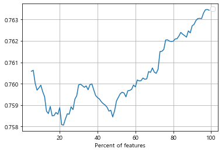

```python
models = [logreg]


# 6개의 모델을 이용해서 가장 잘나온 p를 뽑을 것임
for model in models:

    cv_scores = []

    # 퍼센타일을 5~100프로 모두 살피기 <- 처음에만 100프로 찍고 이후 조절하기
    for percentile in tqdm(range(5,100)):

        X_new = SelectPercentile(percentile = percentile).fit_transform(X_train,y_train)

        # cross_val_score 4번의 평균값 (정수시 skf로 자동으로 들어간다)
        cv_score = cross_val_score(model, X_new, y_train, scoring='roc_auc', cv=skf).mean()

        cv_scores.append((percentile, cv_score))

    # 베스트 percentile과 점수 출력
    best_score = cv_scores[np.argmax([score for _, score in cv_scores])]
    print(model.__class__.__name__, best_score)

    # 모델별 percentile에 따른 성능 그림
    plt.plot([p for p,_ in cv_scores], [score for _, score in cv_scores])
    plt.xlabel('Percent of features')
    plt.legend(loc=0)
    plt.grid()
```

```python
new_range = []

# 6개의 모델을 이용해서 가장 잘나온 p를 뽑을 것임
for model in models:

    cv_scores = []

    # 다른 모델들 과적합 안나면서 성능도 평균적으로 좋은 부분으로 최종채택
    for percentile in tqdm(new_range):

        X_new = SelectPercentile(percentile = percentile).fit_transform(X_train,y_train)

        # cross_val_score 4번의 평균값 (정수시 skf로 자동으로 들어간다)
        cv_score = cross_val_score(model, X_new, y_train, scoring='roc_auc', cv=skf)

        cv_scores.append((percentile, cv_score.mean()))

    # 베스트 percentile과 점수 출력
    best_score = cv_scores[np.argmax([score for _, score in cv_scores])]
    print(model.__class__.__name__, cv_score)
    print(best_score)

    # 모델별 percentile에 따른 성능 그림
    plt.plot([p for p,_ in cv_scores], [score for _, score in cv_scores])
    plt.xlabel('Percent of features')
    plt.legend(loc=0)
    plt.grid()
```

```python
X_test = X_test.fillna({'goods_0_similarity':np.mean(X_test['goods_0_similarity']), 'goods_1_similarity':np.mean(X_test['goods_1_similarity'])})
```

```python
select_p = SelectPercentile(percentile= 98).fit(X_train, y_train)
X_train = select_p.transform(X_train)
X_test = select_p.transform(X_test)
```

[output not shown]

```python
pd.DataFrame(X_train)
```

|  | 0 | 1 | 2 | 3 | 4 | 5 | 6 | 7 | 8 | 9 | 10 | 11 | 12 | 13 | 14 | 15 | 16 | 17 | 18 | 19 | 20 | 21 | 22 | 23 | 24 | ... | 1156 | 1157 | 1158 | … |
| --- | --- | --- | --- | --- | --- | --- | --- | --- | --- | --- | --- | --- | --- | --- | --- | --- | --- | --- | --- | --- | --- | --- | --- | --- | --- | --- | --- | --- | --- | --- |
| 0 | 5.899665e-02 | 5.280996e-02 | 4.896489e-02 | 4.692144e-02 | 5.887605e-02 | 3.703730e-02 | 4.528708e-02 | 0.056775 | 4.558063e-02 | 4.952119e-02 | 5.959244e-02 | 4.511775e-02 | 5.462449e-02 | 4.705761e-02 | 0.061487 | 5.883342e-02 | 2.512778e-02 | 4.515208e-02 | 4.507128e-02 | 0.050417 | 0.037349 | 4.976974e-02 | 4.951488e-02 | 3.703742e-02 | 4.567186e-02 | ... | -0.134003 | -0.113941 | -0.009877 | … |
| 1 | 4.440968e-02 | 3.742162e-02 | 5.923415e-02 | 2.783321e-02 | 2.523422e-02 | 7.106267e-03 | 3.267865e-02 | 0.005263 | 2.856833e-02 | 7.226545e-02 | 2.235206e-02 | 9.817278e-03 | 2.250186e-02 | 1.426914e-02 | 0.024142 | 2.960102e-02 | 2.988188e-02 | 1.449286e-02 | 5.052224e-02 | 0.012466 | 0.006994 | 1.225173e-03 | 3.484410e-02 | 7.933024e-02 | 5.527479e-02 | ... | -0.134003 | -0.043292 | -0.004148 | … |
| 2 | 3.381081e-02 | 8.462013e-03 | 8.081478e-02 | 3.126807e-03 | 3.733460e-02 | 4.156350e-02 | 6.252491e-02 | 0.003031 | 3.383411e-02 | 2.499662e-02 | 1.678573e-02 | 1.322571e-02 | 1.331047e-02 | 1.990806e-02 | 0.026797 | 4.470570e-02 | 5.285054e-03 | 3.717316e-02 | 9.725036e-03 | 0.000963 | 0.000839 | 7.777274e-03 | 4.730411e-02 | 2.759685e-03 | 2.173524e-02 | ... | -0.060017 | -0.011618 | 0.032686 | … |
| 3 | 4.476567e-02 | 3.724468e-02 | 6.270374e-02 | 3.711123e-02 | 4.323265e-02 | 3.776972e-02 | 3.849525e-02 | 0.041409 | 2.866256e-02 | 4.330871e-02 | 5.383167e-02 | 3.393687e-02 | 4.525302e-02 | 2.844671e-02 | 0.029419 | 5.589782e-02 | 2.943322e-02 | 3.370453e-02 | 3.045639e-02 | 0.040457 | 0.046573 | 4.675895e-02 | 2.942423e-02 | 4.083059e-02 | 3.134383e-02 | ... | -0.086869 | -0.044628 | -0.001354 | … |
| 4 | 6.251881e-02 | 2.899562e-02 | 1.460668e-02 | 6.149970e-02 | 4.184485e-02 | 5.260567e-02 | 4.462630e-02 | 0.063573 | 3.777427e-02 | 4.822346e-02 | 6.022044e-02 | 2.236826e-02 | 2.380999e-02 | 1.820231e-02 | 0.046688 | 5.210932e-02 | 1.958533e-02 | 2.550013e-02 | 1.182246e-02 | 0.022583 | 0.020502 | 5.179163e-02 | 5.374951e-02 | 2.011977e-02 | 7.367784e-02 | ... | -0.060017 | -0.024177 | 0.028466 | … |
| ... | ... | ... | ... | ... | ... | ... | ... | ... | ... | ... | ... | ... | ... | ... | ... | ... | ... | ... | ... | ... | ... | ... | ... | ... | ... | ... | ... | ... | ... | … |
| 3495 | 4.867327e-03 | 1.004821e-02 | 1.841670e-03 | 1.046062e-02 | 1.225543e-02 | 3.247649e-02 | 3.132902e-03 | 0.016049 | 3.362139e-02 | 8.664630e-02 | 6.594805e-03 | 1.763941e-02 | 5.992286e-02 | 1.350976e-02 | 0.029732 | 2.829801e-02 | 7.291049e-03 | 9.632668e-03 | 1.842618e-02 | 0.045679 | 0.010909 | 1.522550e-03 | 1.179132e-02 | 1.487208e-02 | 5.360587e-03 | ... | -0.107622 | -0.050094 | 0.062155 | … |
| 3496 | 4.646836e-02 | 7.465217e-02 | 3.738804e-02 | 2.867129e-02 | 2.526517e-02 | 2.221231e-02 | 5.093722e-02 | 0.046614 | 3.622800e-02 | 5.158681e-02 | 8.424698e-02 | 1.986091e-02 | 6.063771e-02 | 7.796669e-02 | 0.050515 | 5.133567e-02 | 3.175574e-02 | 3.903417e-02 | 5.288789e-02 | 0.051552 | 0.055567 | 3.070233e-02 | 3.034973e-02 | 2.393415e-02 | 3.446943e-02 | ... | -0.107622 | -0.090470 | -0.009877 | … |
| 3497 | 0.000000e+00 | 3.725290e-09 | 0.000000e+00 | 0.000000e+00 | 0.000000e+00 | 4.656613e-10 | 0.000000e+00 | 0.000000 | 0.000000e+00 | 0.000000e+00 | 1.862645e-09 | 4.656613e-10 | 0.000000e+00 | 3.725290e-09 | 0.000000 | 0.000000e+00 | 1.862645e-09 | 0.000000e+00 | 0.000000e+00 | 0.000000 | 0.000000 | 0.000000e+00 | 0.000000e+00 | 3.725290e-09 | 0.000000e+00 | ... | 0.003550 | 0.040159 | 0.051017 | … |
| 3498 | 7.450581e-09 | 7.450581e-09 | 1.396984e-09 | 1.490116e-08 | 3.725290e-09 | 0.000000e+00 | 7.450581e-09 | 0.000000 | 5.587935e-09 | 1.396984e-09 | 7.450581e-09 | 0.000000e+00 | 1.117587e-08 | 7.450581e-09 | 0.000000 | 3.725290e-09 | 5.587935e-09 | 1.164153e-10 | 1.490116e-08 | 0.000000 | 0.000000 | 7.450581e-09 | 2.235174e-08 | 0.000000e+00 | 1.490116e-08 | ... | -0.008210 | 0.037271 | 0.052507 | … |
| 3499 | 5.208909e-02 | 5.933618e-02 | 6.242975e-02 | 4.289355e-02 | 3.734662e-02 | 5.185428e-02 | 4.779614e-02 | 0.056293 | 4.049378e-02 | 5.785515e-02 | 7.573969e-02 | 4.436250e-02 | 4.376474e-02 | 5.416920e-02 | 0.049779 | 5.782526e-02 | 4.508354e-02 | 5.732210e-02 | 4.236741e-02 | 0.060247 | 0.039065 | 4.189559e-02 | 4.254751e-02 | 4.341828e-02 | 4.848241e-02 | ... | -0.134003 | -0.111666 | -0.009877 | … |

3500 rows × 1181 columns

```python
pd.DataFrame(X_train).to_csv('X_train_after_percentile_nm&mclas.csv',index=False,encoding='cp949')
pd.DataFrame(X_test).to_csv('X_test_after_percentile_nm&mclas.csv',index=False,encoding='cp949')
```